# Анализ игровых платформ Xbox и PlayStation

# Описание проекта

К рассмотрению представлен интернет-магазин «Стримчик», который продаёт по всему миру компьютерные игры. Из открытых источников доступны исторические данные до 2016 года о продажах игр, оценки пользователей и экспертов, жанры и платформы (например, Xbox или PlayStation). Необходимо выявить определяющие успешность игры закономерности. Это позволит сделать ставку на потенциально популярный продукт и спланировать рекламные кампании.  
В наборе данных попадается аббревиатура ESRB (Entertainment Software Rating Board) — это ассоциация, определяющая возрастной рейтинг компьютерных игр. ESRB оценивает игровой контент и присваивает ему подходящую возрастную категорию, например, «Для взрослых», «Для детей младшего возраста» или «Для подростков».

# Описание данных

- Name — название игры
- Platform — платформа
- Year_of_Release — год выпуска
- Genre — жанр игры
- NA_sales — продажи в Северной Америке (миллионы проданных копий)
- EU_sales — продажи в Европе (миллионы проданных копий)
- JP_sales — продажи в Японии (миллионы проданных копий)
- Other_sales — продажи в других странах (миллионы проданных копий)
- Critic_Score — оценка критиков (максимум 100)
- User_Score — оценка пользователей (максимум 10)
- Rating — рейтинг от организации ESRB (англ. Entertainment Software Rating Board). Эта ассоциация определяет рейтинг компьютерных игр и присваивает им подходящую возрастную категорию.

Данные за 2016 год могут быть неполными.

# 1. Открытие файл с данными и изучение общей информации

Путь к файлу: /datasets/games.csv.

# 2. Подготовка данных

- Заменить названия столбцов (привести к нижнему регистру);
- Преобразовать данных в нужные типы. Описать, в каких столбцах заменили тип данных и почему;
- Обработать пропусков при необходимости: объяснить, почему заполнили пропуски определённым образом или почему не стали это делать; описать причины, которые могли привести к пропускам;
- Обратить внимание на аббревиатуру 'tbd' в столбце с оценкой пользователей. Отдельно разобрать это значение и описать, как его обработать;
- Посчитать суммарные продажи во всех регионах и записать их в отдельный столбец.

# 3. Провести исследовательский анализ данных

- Посмотреть, сколько игр выпускалось в разные годы. Важны ли данные за все периоды?
- Посмотреть, как менялись продажи по платформам. Выбрать платформы с наибольшими суммарными продажами и построить распределение по годам.
- За какой характерный срок появляются новые и исчезают старые платформы?
- Взять данные за соответствующий актуальный период. Актуальный период определить самостоятельно в результате исследования предыдущих вопросов. Основной фактор — эти данные помогут построить прогноз на 2017 год. Не учитывайте в работе данные за предыдущие годы.
- Какие платформы лидируют по продажам, растут или падают? Выберать несколько потенциально прибыльных платформ.
- Построить график «ящик с усами» по глобальным продажам игр в разбивке по платформам. Описать результат.
- Посмотреть, как влияют на продажи внутри одной популярной платформы отзывы пользователей и критиков.
- Построить диаграмму рассеяния и посчитать корреляцию между отзывами и продажами. Сформулировать выводы.
- Соотнести выводы с продажами игр на других платформах.
- Посмотреть на общее распределение игр по жанрам. Что можно сказать о самых прибыльных жанрах? Выделяются ли жанры с высокими и низкими продажами?

# 4. Составить портрет пользователя каждого региона

Определить для пользователя каждого региона (NA, EU, JP):

- Самые популярные платформы (топ-5). Описать различия в долях продаж.
- Самые популярные жанры (топ-5). Пояснить разницу.
- Влияет ли рейтинг ESRB на продажи в отдельном регионе?

# 5. Проверить гипотезы

- Средние пользовательские рейтинги платформ Xbox One и PC одинаковые;
- Средние пользовательские рейтинги жанров Action (англ. «действие», экшен-игры) и Sports (англ. «спортивные соревнования») разные.  
  Задать самостоятельно пороговое значение alpha.  
  Пояснить:  
  Как вы сформулировали нулевую и альтернативную гипотезы;  
  Какой критерий применили для проверки гипотез и почему.

# 6. Написать общий вывод

# 1. Открытие файл с данными и изучение общей информации

```python
# вызов библиотеки pandas
import pandas as pd
# импорт библиотеки matplotlib
import matplotlib.pyplot as plt
# импорт библиотеки numpy
import numpy as np
# импорт библиотеки seaborn
import seaborn as sns
# импорт библиотеки scipy
import scipy
from scipy import stats as st
# импорт библиотеки warnings
import warnings
```

```python
# чтение файла
try:
    games = pd.read_csv(r'c:\\Users\\Юки\\AnaliticData\\1_СБОРНЫЙ_ПРОЕКТ\\games.csv') #, sep='\t')
except:
    games = pd.read_csv('https://code.s3.yandex.net/datasets/games.csv')
```

```python
# вывод на экран датасета
display(games)
# просмотр общей информации о датасете
games.info()
```

|  | Name | Platform | Year_of_Release | Genre | NA_sales | EU_sales | JP_sales | Other_sales | Critic_Score | User_Score | Rating |
| --- | --- | --- | --- | --- | --- | --- | --- | --- | --- | --- | --- |
| 0 | Wii Sports | Wii | 2006.0 | Sports | 41.36 | 28.96 | 3.77 | 8.45 | 76.0 | 8 | E |
| 1 | Super Mario Bros. | NES | 1985.0 | Platform | 29.08 | 3.58 | 6.81 | 0.77 | NaN | NaN | NaN |
| 2 | Mario Kart Wii | Wii | 2008.0 | Racing | 15.68 | 12.76 | 3.79 | 3.29 | 82.0 | 8.3 | E |
| 3 | Wii Sports Resort | Wii | 2009.0 | Sports | 15.61 | 10.93 | 3.28 | 2.95 | 80.0 | 8 | E |
| 4 | Pokemon Red/Pokemon Blue | GB | 1996.0 | Role-Playing | 11.27 | 8.89 | 10.22 | 1.00 | NaN | NaN | NaN |
| ... | ... | ... | ... | ... | ... | ... | ... | ... | ... | ... | ... |
| 16710 | Samurai Warriors: Sanada Maru | PS3 | 2016.0 | Action | 0.00 | 0.00 | 0.01 | 0.00 | NaN | NaN | NaN |
| 16711 | LMA Manager 2007 | X360 | 2006.0 | Sports | 0.00 | 0.01 | 0.00 | 0.00 | NaN | NaN | NaN |
| 16712 | Haitaka no Psychedelica | PSV | 2016.0 | Adventure | 0.00 | 0.00 | 0.01 | 0.00 | NaN | NaN | NaN |
| 16713 | Spirits & Spells | GBA | 2003.0 | Platform | 0.01 | 0.00 | 0.00 | 0.00 | NaN | NaN | NaN |
| 16714 | Winning Post 8 2016 | PSV | 2016.0 | Simulation | 0.00 | 0.00 | 0.01 | 0.00 | NaN | NaN | NaN |

16715 rows × 11 columns

```
<class 'pandas.core.frame.DataFrame'>
RangeIndex: 16715 entries, 0 to 16714
Data columns (total 11 columns):
 #   Column           Non-Null Count  Dtype
---  ------           --------------  -----
 0   Name             16713 non-null  object
 1   Platform         16715 non-null  object
 2   Year_of_Release  16446 non-null  float64
 3   Genre            16713 non-null  object
 4   NA_sales         16715 non-null  float64
 5   EU_sales         16715 non-null  float64
 6   JP_sales         16715 non-null  float64
 7   Other_sales      16715 non-null  float64
 8   Critic_Score     8137 non-null   float64
 9   User_Score       10014 non-null  object
 10  Rating           9949 non-null   object
dtypes: float64(6), object(5)
memory usage: 1.4+ MB
```

```python
games_isnull_Value = games.isnull().sum().sort_values(ascending = False)
games_isnull_Percent = round(games.isnull().mean().sort_values(ascending = False)*100,2)
games_isnull = pd.concat([games_isnull_Value, games_isnull_Percent], axis=1, keys=['Пропущенные значения', 'Процент'])
games_isnull
```

|  | Пропущенные значения | Процент |
| --- | --- | --- |
| Critic_Score | 8578 | 51.32 |
| Rating | 6766 | 40.48 |
| User_Score | 6701 | 40.09 |
| Year_of_Release | 269 | 1.61 |
| Name | 2 | 0.01 |
| Genre | 2 | 0.01 |
| Platform | 0 | 0.00 |
| NA_sales | 0 | 0.00 |
| EU_sales | 0 | 0.00 |
| JP_sales | 0 | 0.00 |
| Other_sales | 0 | 0.00 |

**Вывод:**

- Загруженный датафрейм содержит 16715 наблюдений и 11 признаков;
- 6 признака числовые, остальные 5 - категориальные, однако у некоторых признаков необходимо изменить тип: столбец User_Score содержит числовые данные, а столбец Year_of_Release - информацию о дате;
- в таблице почти нет пропусков данных в данных о названиях платформ, игр, жанров и продажах, небольшое количество пропусков в годах выпуска и достаточно много пропусков в столбцах оценок и рейтинга - возможно, эти пропуски не случайны;
- названия столбцов кажутся правильными, но требуют приведению к нижнему регистру.

# 2. Подготовка данных

**Переименование столбцов, перевод названий в нижний регистр**

```python
games.columns = games.columns.str.lower()
games.head()
```

|  | name | platform | year_of_release | genre | na_sales | eu_sales | jp_sales | other_sales | critic_score | user_score | rating |
| --- | --- | --- | --- | --- | --- | --- | --- | --- | --- | --- | --- |
| 0 | Wii Sports | Wii | 2006.0 | Sports | 41.36 | 28.96 | 3.77 | 8.45 | 76.0 | 8 | E |
| 1 | Super Mario Bros. | NES | 1985.0 | Platform | 29.08 | 3.58 | 6.81 | 0.77 | NaN | NaN | NaN |
| 2 | Mario Kart Wii | Wii | 2008.0 | Racing | 15.68 | 12.76 | 3.79 | 3.29 | 82.0 | 8.3 | E |
| 3 | Wii Sports Resort | Wii | 2009.0 | Sports | 15.61 | 10.93 | 3.28 | 2.95 | 80.0 | 8 | E |
| 4 | Pokemon Red/Pokemon Blue | GB | 1996.0 | Role-Playing | 11.27 | 8.89 | 10.22 | 1.00 | NaN | NaN | NaN |

**Обработаем пропуски**

```python
# посмотрим на строки с пропущенными значениями в именах игр
games[games['name'].isna()]
```

|  | name | platform | year_of_release | genre | na_sales | eu_sales | jp_sales | other_sales | critic_score | user_score | rating |
| --- | --- | --- | --- | --- | --- | --- | --- | --- | --- | --- | --- |
| 659 | NaN | GEN | 1993.0 | NaN | 1.78 | 0.53 | 0.00 | 0.08 | NaN | NaN | NaN |
| 14244 | NaN | GEN | 1993.0 | NaN | 0.00 | 0.00 | 0.03 | 0.00 | NaN | NaN | NaN |

```python
games = games.dropna(subset=['name'])
```

Пропуски в столбце **name** соответствуют отсутствующим значениям столбца **genre** - скорее всего связано с техническим сбоем, ввиду малого количества - удалим данные строки.

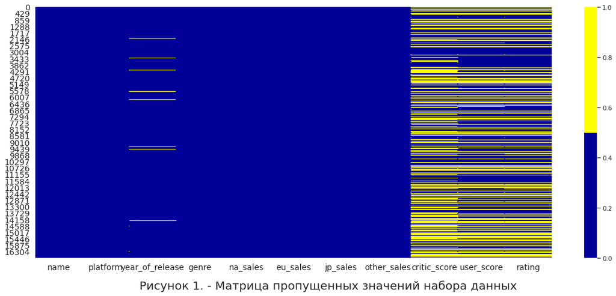

```python
# c помощью библиотеки seaborn построим тепловую карту для визуализации данных
sns.heatmap(games.isnull(), cmap=sns.color_palette(['#000099', '#ffff00']))
sns.set(rc={'figure.figsize':(20,8)})
# Оформление графика
plt.xticks(fontsize=14)
plt.yticks(fontsize=14)
plt.figtext(0.25, 0.03, "Рисунок 1. - Матрица пропущенных значений набора данных", fontsize=20)
plt.show()
```

Исходя из визуализации можем метить:

- пропуски значений в столбце **дата выпуска** единичны, удаляя строки с пропущенными значениями по данному признаку - не потеряем ценной информации;
- основная часть пропущенных данных содержится в столбцах оценок и рейтинга;
- пропуски соответствуют отсутствующим значениям почти для всех строк в столбцах оценок и рейтинга - удалять строки с отсутствующими в них значениями не будем.  
  Видимо выборка содержит неоцененные по определенным причинам игры в связи с чем пропуски не случайны.

```python
# удалим строки с пропущенными значениями по столбцу year_of_release
#games[games['year_of_release'].isnull()]
games = games.dropna(subset=['year_of_release'])
```

```python
# просмотр уникальных значений столбца пользовательских оценок
print(games['user_score'].unique())
```

```
['8' nan '8.3' '8.5' '6.6' '8.4' '8.6' '7.7' '6.3' '7.4' '8.2' '9' '7.9'
 '8.1' '8.7' '7.1' '3.4' '5.3' '4.8' '3.2' '8.9' '6.4' '7.8' '7.5' '2.6'
 '7.2' '9.2' '7' '7.3' '4.3' '7.6' '5.7' '5' '9.1' '6.5' 'tbd' '8.8' '6.9'
 '9.4' '6.8' '6.1' '6.7' '5.4' '4' '4.9' '4.5' '9.3' '6.2' '4.2' '6' '3.7'
 '4.1' '5.8' '5.6' '5.5' '4.4' '4.6' '5.9' '3.9' '3.1' '2.9' '5.2' '3.3'
 '4.7' '5.1' '3.5' '2.5' '1.9' '3' '2.7' '2.2' '2' '9.5' '2.1' '3.6' '2.8'
 '1.8' '3.8' '0' '1.6' '9.6' '2.4' '1.7' '1.1' '0.3' '1.5' '0.7' '1.2'
 '2.3' '0.5' '1.3' '0.2' '0.6' '1.4' '0.9' '1' '9.7']
```

```python
# просмотр уникальных значений столбца оценок критиков
print(games['critic_score'].unique())
```

```
[76. nan 82. 80. 89. 58. 87. 91. 61. 97. 95. 77. 88. 83. 94. 93. 85. 86.
 98. 96. 90. 84. 73. 74. 78. 92. 71. 72. 68. 62. 49. 67. 81. 66. 56. 79.
 70. 59. 64. 75. 60. 63. 69. 50. 25. 42. 44. 55. 48. 57. 29. 47. 65. 54.
 20. 53. 37. 38. 33. 52. 30. 32. 43. 45. 51. 40. 46. 39. 34. 41. 36. 31.
 27. 35. 26. 19. 28. 23. 24. 21. 17. 13.]
```

```python
# просмотр уникальных значений столбца рейтинга
print(games['rating'].unique())
```

```
['E' nan 'M' 'T' 'E10+' 'K-A' 'AO' 'EC' 'RP']
```

```python
# осуществим замену пропущенных значений в столбцах critic_score, user_score,rating на пустые значения:
games['critic_score']=games['critic_score'].fillna('')
games['user_score']=games['user_score'].fillna('')
games['rating']=games['rating'].fillna('')
```

```python
games.isnull().sum()
```

```
name               0
platform           0
year_of_release    0
genre              0
na_sales           0
eu_sales           0
jp_sales           0
other_sales        0
critic_score       0
user_score         0
rating             0
dtype: int64
```

После проведенных операций выборка не содержит пропуски.

**Преобразуем данных в нужные типы:**

```python
games['year_of_release'] = games['year_of_release'].astype('int')
games.head()
```

|  | name | platform | year_of_release | genre | na_sales | eu_sales | jp_sales | other_sales | critic_score | user_score | rating |
| --- | --- | --- | --- | --- | --- | --- | --- | --- | --- | --- | --- |
| 0 | Wii Sports | Wii | 2006 | Sports | 41.36 | 28.96 | 3.77 | 8.45 | 76.0 | 8 | E |
| 1 | Super Mario Bros. | NES | 1985 | Platform | 29.08 | 3.58 | 6.81 | 0.77 |  |  |  |
| 2 | Mario Kart Wii | Wii | 2008 | Racing | 15.68 | 12.76 | 3.79 | 3.29 | 82.0 | 8.3 | E |
| 3 | Wii Sports Resort | Wii | 2009 | Sports | 15.61 | 10.93 | 3.28 | 2.95 | 80.0 | 8 | E |
| 4 | Pokemon Red/Pokemon Blue | GB | 1996 | Role-Playing | 11.27 | 8.89 | 10.22 | 1.00 |  |  |  |

```python
# преобразуем значения столбца "год выпуска" в тип datetime
games['year_of_release']=pd.to_datetime(games['year_of_release'], format='%Y').dt.year
games.head()
```

|  | name | platform | year_of_release | genre | na_sales | eu_sales | jp_sales | other_sales | critic_score | user_score | rating |
| --- | --- | --- | --- | --- | --- | --- | --- | --- | --- | --- | --- |
| 0 | Wii Sports | Wii | 2006 | Sports | 41.36 | 28.96 | 3.77 | 8.45 | 76.0 | 8 | E |
| 1 | Super Mario Bros. | NES | 1985 | Platform | 29.08 | 3.58 | 6.81 | 0.77 |  |  |  |
| 2 | Mario Kart Wii | Wii | 2008 | Racing | 15.68 | 12.76 | 3.79 | 3.29 | 82.0 | 8.3 | E |
| 3 | Wii Sports Resort | Wii | 2009 | Sports | 15.61 | 10.93 | 3.28 | 2.95 | 80.0 | 8 | E |
| 4 | Pokemon Red/Pokemon Blue | GB | 1996 | Role-Playing | 11.27 | 8.89 | 10.22 | 1.00 |  |  |  |

```python
games['user_score'].unique()
```

```
array(['8', '', '8.3', '8.5', '6.6', '8.4', '8.6', '7.7', '6.3', '7.4',
       '8.2', '9', '7.9', '8.1', '8.7', '7.1', '3.4', '5.3', '4.8', '3.2',
       '8.9', '6.4', '7.8', '7.5', '2.6', '7.2', '9.2', '7', '7.3', '4.3',
       '7.6', '5.7', '5', '9.1', '6.5', 'tbd', '8.8', '6.9', '9.4', '6.8',
       '6.1', '6.7', '5.4', '4', '4.9', '4.5', '9.3', '6.2', '4.2', '6',
       '3.7', '4.1', '5.8', '5.6', '5.5', '4.4', '4.6', '5.9', '3.9',
       '3.1', '2.9', '5.2', '3.3', '4.7', '5.1', '3.5', '2.5', '1.9', '3',
       '2.7', '2.2', '2', '9.5', '2.1', '3.6', '2.8', '1.8', '3.8', '0',
       '1.6', '9.6', '2.4', '1.7', '1.1', '0.3', '1.5', '0.7', '1.2',
       '2.3', '0.5', '1.3', '0.2', '0.6', '1.4', '0.9', '1', '9.7'],
      dtype=object)
```

**tbd** - аббревиатура расшифровывается очень просто - To Be Determined, то есть "Будет определено". Таким образом строки, содержащие аббревиатуру tbd фактически имеют нулевые/пропущеныые значания. Выполним преобразование признака **user_score** в тип float, при этом зададим условие преобразования некорректного значения в NAN, а далее заменим пропуски на пустые значения.

```python
games[games['user_score']=='tbd'].head()
```

|  | name | platform | year_of_release | genre | na_sales | eu_sales | jp_sales | other_sales | critic_score | user_score | rating |
| --- | --- | --- | --- | --- | --- | --- | --- | --- | --- | --- | --- |
| 119 | Zumba Fitness | Wii | 2010 | Sports | 3.45 | 2.59 | 0.0 | 0.66 |  | tbd | E |
| 301 | Namco Museum: 50th Anniversary | PS2 | 2005 | Misc | 2.08 | 1.35 | 0.0 | 0.54 | 61.0 | tbd | E10+ |
| 520 | Zumba Fitness 2 | Wii | 2011 | Sports | 1.51 | 1.03 | 0.0 | 0.27 |  | tbd | T |
| 645 | uDraw Studio | Wii | 2010 | Misc | 1.65 | 0.57 | 0.0 | 0.20 | 71.0 | tbd | E |
| 718 | Just Dance Kids | Wii | 2010 | Misc | 1.52 | 0.54 | 0.0 | 0.18 |  | tbd | E |

```python
games['user_score']=pd.to_numeric(games['user_score'], errors='coerce').fillna('')
```

```python
#проверим наличие дубликатов
games[games.duplicated()]
```

|  | name | platform | year_of_release | genre | na_sales | eu_sales | jp_sales | other_sales | critic_score | user_score | rating |
| --- | --- | --- | --- | --- | --- | --- | --- | --- | --- | --- | --- |

**Посчитаем суммарные продажи во всех регионах и запишем их в отдельный столбец**

```python
#games['total_sales']=games[['na_sales','eu_sales','jp_sales','other_sales']].sum(axis=1)
games['total_sales'] = games.loc[: , 'na_sales':'other_sales'].sum(axis=1)
#games['total_sales']=games['na_sales']+games['eu_sales']+games['jp_sales']+games['other_sales']

display(games)
```

|  | name | platform | year_of_release | genre | na_sales | eu_sales | jp_sales | other_sales | critic_score | user_score | rating | total_sales |
| --- | --- | --- | --- | --- | --- | --- | --- | --- | --- | --- | --- | --- |
| 0 | Wii Sports | Wii | 2006 | Sports | 41.36 | 28.96 | 3.77 | 8.45 | 76.0 | 8.0 | E | 82.54 |
| 1 | Super Mario Bros. | NES | 1985 | Platform | 29.08 | 3.58 | 6.81 | 0.77 |  |  |  | 40.24 |
| 2 | Mario Kart Wii | Wii | 2008 | Racing | 15.68 | 12.76 | 3.79 | 3.29 | 82.0 | 8.3 | E | 35.52 |
| 3 | Wii Sports Resort | Wii | 2009 | Sports | 15.61 | 10.93 | 3.28 | 2.95 | 80.0 | 8.0 | E | 32.77 |
| 4 | Pokemon Red/Pokemon Blue | GB | 1996 | Role-Playing | 11.27 | 8.89 | 10.22 | 1.00 |  |  |  | 31.38 |
| ... | ... | ... | ... | ... | ... | ... | ... | ... | ... | ... | ... | ... |
| 16710 | Samurai Warriors: Sanada Maru | PS3 | 2016 | Action | 0.00 | 0.00 | 0.01 | 0.00 |  |  |  | 0.01 |
| 16711 | LMA Manager 2007 | X360 | 2006 | Sports | 0.00 | 0.01 | 0.00 | 0.00 |  |  |  | 0.01 |
| 16712 | Haitaka no Psychedelica | PSV | 2016 | Adventure | 0.00 | 0.00 | 0.01 | 0.00 |  |  |  | 0.01 |
| 16713 | Spirits & Spells | GBA | 2003 | Platform | 0.01 | 0.00 | 0.00 | 0.00 |  |  |  | 0.01 |
| 16714 | Winning Post 8 2016 | PSV | 2016 | Simulation | 0.00 | 0.00 | 0.01 | 0.00 |  |  |  | 0.01 |

16444 rows × 12 columns

```python
games.info()
```

```
<class 'pandas.core.frame.DataFrame'>
Int64Index: 16444 entries, 0 to 16714
Data columns (total 12 columns):
 #   Column           Non-Null Count  Dtype
---  ------           --------------  -----
 0   name             16444 non-null  object
 1   platform         16444 non-null  object
 2   year_of_release  16444 non-null  int64
 3   genre            16444 non-null  object
 4   na_sales         16444 non-null  float64
 5   eu_sales         16444 non-null  float64
 6   jp_sales         16444 non-null  float64
 7   other_sales      16444 non-null  float64
 8   critic_score     16444 non-null  object
 9   user_score       16444 non-null  object
 10  rating           16444 non-null  object
 11  total_sales      16444 non-null  float64
dtypes: float64(5), int64(1), object(6)
memory usage: 1.6+ MB
```

**Вывод:**  
Удаление строк с пропущенными значениями в столбцах рейтинга и оценок пользователей и критиков не было выполнено, т.к. данные пропущенны не случайно - при обработке зависимостей в вышеназванных столбцах данный факт будет учтен.

# Исследовательский анализ данных

1. Посмотрим, сколько игр выпускалось в разные годы.

```python
#Подсчет количества выпускаемых игр в разные годы
games.groupby('year_of_release')['name'].count()
```

```
year_of_release
1980       9
1981      46
1982      36
1983      17
1984      14
1985      14
1986      21
1987      16
1988      15
1989      17
1990      16
1991      41
1992      43
1993      60
```

[output cut: 24 more lines]

Количество выпускаемых игр с 1980 (9 игр) по 2008 (1427 игр) увеличивалось, с 2009 (1426 игр) - пошло на спад, в 2016 количнство выпускаемых игр составило 502 штуки.

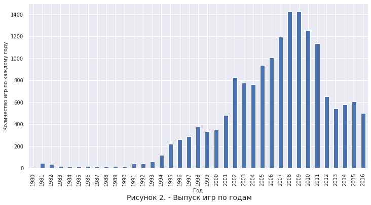

```python
games.groupby('year_of_release').name.count().plot(kind='bar',figsize=(12,6))
plt.xlabel("Год", fontsize=10)
plt.ylabel('Количество игр по каждому году', fontsize=10)
plt.xticks(fontsize=10)
plt.yticks(fontsize=10)
plt.figtext(0.35, -0.02, "Рисунок 2. - Выпуск игр по годам", fontsize=14)
plt.show()
```

**Вывод:** Диаграмма показывает, что начиная с 1980 г. ростет выпуск игр, максимальный значения по количеству достиглись в 2008-2099 гг (более 1400 игр в год), однако начиая с 2010 г. наблюдается спад в выпуске игр - это можно объяснить популярность игр в мобильных телефонах.

1. Посмотрим, как менялись продажи по платформам. Выберем платформы с наибольшими суммарными продажами и построим распределение по годам.

```python
#pivot_table, где index - год, columns - платформа, values - суммарные продажи (новый столбец). Потом по этой таблице строил sns.lineplot, в котором x и y год и продажи соответственно, а hue = 'platform'
games_p=games.pivot_table(index='year_of_release', columns='platform', values='total_sales',aggfunc='sum')

#sns.lineplot(data=games_p,x='year_of_release', y='total_sales', hue = 'platform', figsize=(10, 6))
#plt.figtext(0.4, 0.05, "Рис.5 - Гистограммs суммарных продаж по годам для платформ", fontsize=16)
#plt.show()
games_p
```

| platform year_of_release | 2600 | 3DO | 3DS | DC | DS | GB | GBA | GC | GEN | GG | ... | SAT | SCD | SNES | TG16 | WS | Wii | WiiU | X360 | XB | XOne |
| --- | --- | --- | --- | --- | --- | --- | --- | --- | --- | --- | --- | --- | --- | --- | --- | --- | --- | --- | --- | --- | --- |
| 1980 | 11.38 | NaN | NaN | NaN | NaN | NaN | NaN | NaN | NaN | NaN | ... | NaN | NaN | NaN | NaN | NaN | NaN | NaN | NaN | NaN | NaN |
| 1981 | 35.68 | NaN | NaN | NaN | NaN | NaN | NaN | NaN | NaN | NaN | ... | NaN | NaN | NaN | NaN | NaN | NaN | NaN | NaN | NaN | NaN |
| 1982 | 28.88 | NaN | NaN | NaN | NaN | NaN | NaN | NaN | NaN | NaN | ... | NaN | NaN | NaN | NaN | NaN | NaN | NaN | NaN | NaN | NaN |
| 1983 | 5.84 | NaN | NaN | NaN | NaN | NaN | NaN | NaN | NaN | NaN | ... | NaN | NaN | NaN | NaN | NaN | NaN | NaN | NaN | NaN | NaN |
| 1984 | 0.27 | NaN | NaN | NaN | NaN | NaN | NaN | NaN | NaN | NaN | ... | NaN | NaN | NaN | NaN | NaN | NaN | NaN | NaN | NaN | NaN |
| 1985 | 0.45 | NaN | NaN | NaN | 0.02 | NaN | NaN | NaN | NaN | NaN | ... | NaN | NaN | NaN | NaN | NaN | NaN | NaN | NaN | NaN | NaN |
| 1986 | 0.67 | NaN | NaN | NaN | NaN | NaN | NaN | NaN | NaN | NaN | ... | NaN | NaN | NaN | NaN | NaN | NaN | NaN | NaN | NaN | NaN |
| 1987 | 1.94 | NaN | NaN | NaN | NaN | NaN | NaN | NaN | NaN | NaN | ... | NaN | NaN | NaN | NaN | NaN | NaN | NaN | NaN | NaN | NaN |
| 1988 | 0.74 | NaN | NaN | NaN | NaN | 1.43 | NaN | NaN | NaN | NaN | ... | NaN | NaN | NaN | NaN | NaN | NaN | NaN | NaN | NaN | NaN |
| 1989 | 0.63 | NaN | NaN | NaN | NaN | 64.97 | NaN | NaN | NaN | NaN | ... | NaN | NaN | NaN | NaN | NaN | NaN | NaN | NaN | NaN | NaN |
| 1990 | NaN | NaN | NaN | NaN | NaN | 4.89 | NaN | NaN | 2.60 | NaN | ... | NaN | NaN | 26.15 | NaN | NaN | NaN | NaN | NaN | NaN | NaN |
| 1991 | NaN | NaN | NaN | NaN | NaN | 5.57 | NaN | NaN | 4.33 | NaN | ... | NaN | NaN | 16.22 | NaN | NaN | NaN | NaN | NaN | NaN | NaN |
| 1992 | NaN | NaN | NaN | NaN | NaN | 25.49 | NaN | NaN | 12.64 | 0.04 | ... | NaN | NaN | 32.98 | NaN | NaN | NaN | NaN | NaN | NaN | NaN |
| 1993 | NaN | NaN | NaN | NaN | NaN | NaN | NaN | NaN | 0.65 | NaN | ... | NaN | 1.50 | 40.02 | NaN | NaN | NaN | NaN | NaN | NaN | NaN |
| 1994 | NaN | 0.02 | NaN | NaN | NaN | 12.18 | NaN | NaN | 8.13 | NaN | ... | 3.65 | 0.36 | 35.08 | NaN | NaN | NaN | NaN | NaN | NaN | NaN |
| 1995 | NaN | 0.08 | NaN | NaN | NaN | 3.60 | NaN | NaN | NaN | NaN | ... | 11.57 | NaN | 32.20 | 0.16 | NaN | NaN | NaN | NaN | NaN | NaN |
| 1996 | NaN | NaN | NaN | NaN | NaN | 36.03 | NaN | NaN | NaN | NaN | ... | 7.69 | NaN | 15.92 | NaN | NaN | NaN | NaN | NaN | NaN | NaN |
| 1997 | NaN | NaN | NaN | NaN | NaN | 6.37 | NaN | NaN | NaN | NaN | ... | 6.77 | NaN | 0.99 | NaN | NaN | NaN | NaN | NaN | NaN | NaN |
| 1998 | NaN | NaN | NaN | 3.38 | NaN | 26.90 | NaN | NaN | NaN | NaN | ... | 3.82 | NaN | 0.22 | NaN | NaN | NaN | NaN | NaN | NaN | NaN |
| 1999 | NaN | NaN | NaN | 5.16 | NaN | 38.00 | NaN | NaN | NaN | NaN | ... | 0.09 | NaN | 0.26 | NaN | 0.46 | NaN | NaN | NaN | NaN | NaN |
| 2000 | NaN | NaN | NaN | 5.99 | NaN | 19.76 | 0.07 | NaN | NaN | NaN | ... | NaN | NaN | NaN | NaN | 0.68 | NaN | NaN | NaN | 0.99 | NaN |
| 2001 | NaN | NaN | NaN | 1.07 | NaN | 9.24 | 61.53 | 26.34 | NaN | NaN | ... | NaN | NaN | NaN | NaN | 0.28 | NaN | NaN | NaN | 22.26 | NaN |
| 2002 | NaN | NaN | NaN | 0.29 | NaN | NaN | 74.16 | 51.81 | NaN | NaN | ... | NaN | NaN | NaN | NaN | NaN | NaN | NaN | NaN | 48.01 | NaN |
| 2003 | NaN | NaN | NaN | NaN | NaN | NaN | 56.67 | 50.61 | NaN | NaN | ... | NaN | NaN | NaN | NaN | NaN | NaN | NaN | NaN | 55.04 | NaN |
| 2004 | NaN | NaN | NaN | NaN | 17.27 | NaN | 77.91 | 28.82 | NaN | NaN | ... | NaN | NaN | NaN | NaN | NaN | NaN | NaN | NaN | 65.42 | NaN |
| 2005 | NaN | NaN | NaN | NaN | 130.14 | NaN | 33.86 | 27.62 | NaN | NaN | ... | NaN | NaN | NaN | NaN | NaN | NaN | NaN | 8.25 | 49.08 | NaN |
| 2006 | NaN | NaN | NaN | NaN | 119.81 | NaN | 5.28 | 11.26 | NaN | NaN | ... | NaN | NaN | NaN | NaN | NaN | 137.15 | NaN | 51.62 | 10.04 | NaN |
| 2007 | NaN | NaN | NaN | 0.02 | 146.94 | NaN | 3.40 | 0.27 | NaN | NaN | ... | NaN | NaN | NaN | NaN | NaN | 152.77 | NaN | 95.41 | 0.55 | NaN |
| 2008 | NaN | NaN | NaN | 0.04 | 145.31 | NaN | NaN | NaN | NaN | NaN | ... | NaN | NaN | NaN | NaN | NaN | 171.32 | NaN | 135.26 | 0.18 | NaN |
| 2009 | NaN | NaN | NaN | NaN | 119.54 | NaN | NaN | NaN | NaN | NaN | ... | NaN | NaN | NaN | NaN | NaN | 206.97 | NaN | 120.29 | NaN | NaN |
| 2010 | NaN | NaN | NaN | NaN | 85.02 | NaN | NaN | NaN | NaN | NaN | ... | NaN | NaN | NaN | NaN | NaN | 127.95 | NaN | 170.03 | NaN | NaN |
| 2011 | NaN | NaN | 63.20 | NaN | 26.18 | NaN | NaN | NaN | NaN | NaN | ... | NaN | NaN | NaN | NaN | NaN | 59.65 | NaN | 143.84 | NaN | NaN |
| 2012 | NaN | NaN | 51.36 | NaN | 11.01 | NaN | NaN | NaN | NaN | NaN | ... | NaN | NaN | NaN | NaN | NaN | 21.71 | 17.56 | 99.74 | NaN | NaN |
| 2013 | NaN | NaN | 56.57 | NaN | 1.54 | NaN | NaN | NaN | NaN | NaN | ... | NaN | NaN | NaN | NaN | NaN | 8.59 | 21.65 | 88.58 | NaN | 18.96 |
| 2014 | NaN | NaN | 43.76 | NaN | NaN | NaN | NaN | NaN | NaN | NaN | ... | NaN | NaN | NaN | NaN | NaN | 3.75 | 22.03 | 34.74 | NaN | 54.07 |
| 2015 | NaN | NaN | 27.78 | NaN | NaN | NaN | NaN | NaN | NaN | NaN | ... | NaN | NaN | NaN | NaN | NaN | 1.14 | 16.35 | 11.96 | NaN | 60.14 |
| 2016 | NaN | NaN | 15.14 | NaN | NaN | NaN | NaN | NaN | NaN | NaN | ... | NaN | NaN | NaN | NaN | NaN | 0.18 | 4.60 | 1.52 | NaN | 26.15 |

37 rows × 31 columns

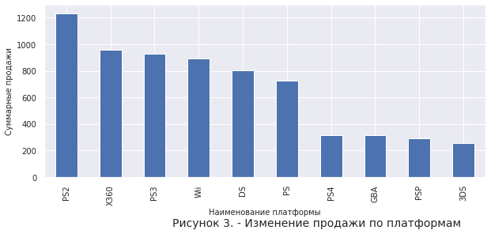

```python
games.groupby('platform')['total_sales'].sum().sort_values(ascending=False)[:10].plot(kind='bar',figsize=(10,4))
plt.xlabel("Наименование платформы", fontsize=10)
plt.ylabel('Суммарные продажи', fontsize=10)
plt.xticks(fontsize=10)
plt.yticks(fontsize=10)
plt.figtext(0.35, -0.09, "Рисунок 3. - Изменение продажи по платформам", fontsize=14)
plt.show()
```

**Вывод:** Распределение показывает, что лидерами рынка продаж являются платформы: PS2, X360, PS3, Wii, DS, PS. Максимальные суммарные продажи принесла платформа **PS2**

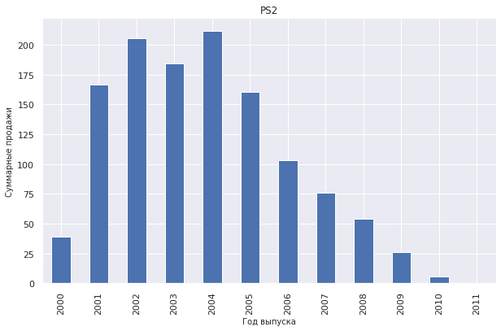

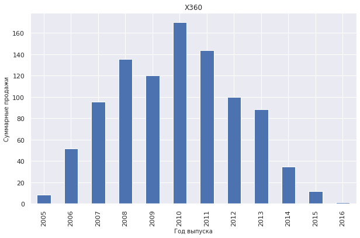

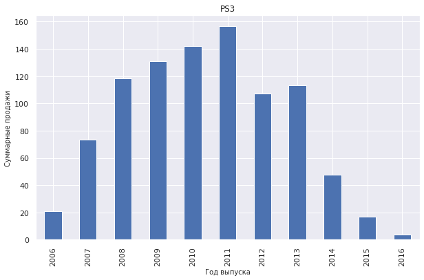

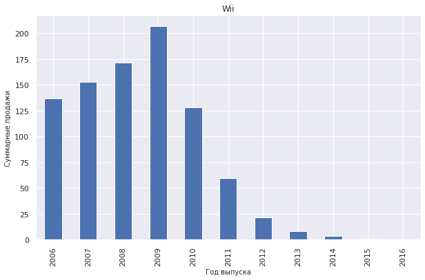

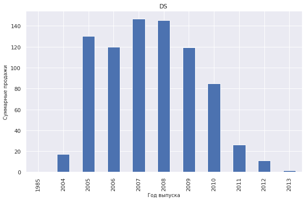

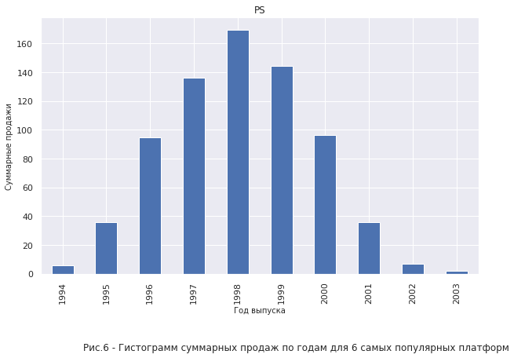

```python
# рассмотрим жизненный цикл на примере патформ с наибольшими суммарными продажами
(games.query('platform=="PS2"').groupby('year_of_release')['total_sales'].sum()
    .plot(kind='bar', grid=True,figsize=(10,6)))
plt.title('PS2') # присвоение заголовка гистограмме
plt.xlabel("Год выпуска", fontsize=10)
plt.ylabel('Суммарные продажи', fontsize=10)
plt.show()
(games.query('platform=="X360"').groupby('year_of_release')['total_sales'].sum()
    .plot(kind='bar', grid=True,figsize=(10,6)))
plt.title('X360') # присвоение заголовка гистограмме
plt.xlabel("Год выпуска", fontsize=10)
plt.ylabel('Суммарные продажи', fontsize=10)
plt.show()
(games.query('platform=="PS3"').groupby('year_of_release')['total_sales'].sum()
    .plot(kind='bar', grid=True,figsize=(10,6)))
plt.title('PS3') # присвоение заголовка гистограмме
plt.xlabel("Год выпуска", fontsize=10)
plt.ylabel('Суммарные продажи', fontsize=10)
plt.show()
(games.query('platform=="Wii"').groupby('year_of_release')['total_sales'].sum()
    .plot(kind='bar', grid=True,figsize=(10,6)))
plt.title('Wii') # присвоение заголовка гистограмме
plt.xlabel("Год выпуска", fontsize=10)
plt.ylabel('Суммарные продажи', fontsize=10)
plt.show()
(games.query('platform=="DS"').groupby('year_of_release')['total_sales'].sum()
    .plot(kind='bar', grid=True,figsize=(10,6)))
plt.title('DS') # присвоение заголовка гистограмме
plt.xlabel("Год выпуска", fontsize=10)
plt.ylabel('Суммарные продажи', fontsize=10)
plt.show()
(games.query('platform=="PS"').groupby('year_of_release')['total_sales'].sum()
    .plot(kind='bar', grid=True,figsize=(10,6)))
plt.title('PS') # присвоение заголовка гистограмме
#plt.xticks(fontsize=10)
#plt.yticks(fontsize=10)
plt.xlabel("Год выпуска", fontsize=10)
plt.ylabel('Суммарные продажи', fontsize=10)
plt.figtext(0.2, -0.1, "Рис.6 - Гистограмм суммарных продаж по годам для 6 самых популярных платформ")
plt.show()
```

1. Выявим за какой характерный срок появляются новые и исчезают старые платформы?

[output not shown]

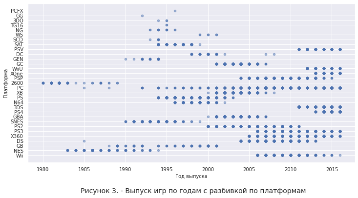

```python
games.plot(x='year_of_release', y='platform', kind='scatter', figsize=(12, 6), grid=True, alpha=0.5)
plt.xlabel("Год выпуска", fontsize=10)
plt.ylabel('Платформа', fontsize=10)
plt.xticks(fontsize=10)
plt.yticks(fontsize=10)
plt.figtext(0.25, -0.02, "Рисунок 3. - Выпуск игр по годам с разбивкой по платформам", fontsize=14)
plt.show()
```